# Data Analysis Using Statistical Packages: Organizing data

Sho Kuroda / 黒田翔

2024年3月 (Last update: 2024年3月)

# 1 Packages in R

パッケージには大別すると次の3種類がある：

1. Rをインストールした時に自動的にインストールされており，Rを起動したときにデフォルトで使えるように設定されているもの（`base::c`, `utils::str`, etc.）
2. Rをインストールした時に自動的にインストールされているが，Rを起動したときにデフォルトでは読み込まれていないもの（`MASS:Boston`, `Matrix::Cholesky`, etc.）
   - `library(ライブラリ名)` で読み込むか，`ライブラリ名::関数名` で呼び出す
3. ユーザーが自分でインストールしなければ使えないもの（`tidyverse`, `data.table`, etc.）
   - `install.packages("パッケージ名")` でインストールし（最初の一度だけ実行），`library(パッケージ名)` で読み込む（Rを起動する度に実行）

補足：同じ名前の関数が複数のパッケージで使用されている場合があるので，常に `ライブラリ名::関数名` の形式でパッケージを指定するのを好む人もいる．

## 1.1 `tidyverse` package

Load the `tidyverse`, a package (or more precisely, a bundle of packages) for manipulating, extracting, and processing data.

データの整理・操作は `tidyverse` というパッケージに含まれる関数を使うのが一般的．

```r
install.packages("tidyverse")  # run for the first time only
```

```r
library(tidyverse)
```

Important function in `dplyr` (pronounced “dee-ply-er”) package:

- `filter` … fetch only the subset (rows) we’re interested in
- `select` … select one or multiple columns (variables)
- `mutate` … creates new columns (variables)
- `rename` … change columns (variables) name
- `left_join` … join (merge) two datasets
- `summarise` … summarize data
- `group_by` … group the rows ** Note: `group_by` alone will not give any output; it should be followed by `summarise` function.

## 1.2 `ggplot2` package

データ可視化のためのパッケージ． `plot` のようなデフォルトで使える関数と比べて文法に癖があるが，慣れれば論文に使える程度に綺麗な図を出力できる．

`plot` 関数はこれ単体でグラフを描画してくれるが，ggplot2 パッケージを使用する場合は `ggplot` 関数でデータと属性（X軸の変数，Y軸の変数，色に対応する変数，サイズに対応する変数）を指定し，次いで `geom_xxx` 関数でジオメトリ（点，線，棒，etc.）を指定するという2段階で描画する．

`library(tidyverse)` を実行すると `ggplot2` も自動的に読み込まれる．

# 2 Example of The Beatles data frame

## 2.1 Create “tibble” object

`data.frame` で作成したデータフレームのオブジェクトより少し扱いやすいデータフレームのオブジェクトを `tibble::tibble` 関数で作成できる．

```r
beatles <- tibble::tibble(name = c("John", "Paul", "George", "Ringo"),
                          born = c(1940, 1942, 1943, 1940),
                          decease = c(1980, NA, NA, NA),
                          height = c(179, 180, 178, 170))
beatles
```

```
## # A tibble: 4 × 4
##   name    born decease height
##   <chr>  <dbl>   <dbl>  <dbl>
## 1 John    1940    1980    179
## 2 Paul    1942      NA    180
## 3 George  1943      NA    178
## 4 Ringo   1940      NA    170
```

## 2.2 `filter`

残す行（observation）の条件を指定する． 複数の条件を指定することもできる．

```r
beatles %>% filter(born >= 1941)
```

```
## # A tibble: 2 × 4
##   name    born decease height
##   <chr>  <dbl>   <dbl>  <dbl>
## 1 Paul    1942      NA    180
## 2 George  1943      NA    178
```

```r
beatles %>% filter(born >= 1941 & height < 180)
```

```
## # A tibble: 1 × 4
##   name    born decease height
##   <chr>  <dbl>   <dbl>  <dbl>
## 1 George  1943      NA    178
```

## 2.3 `select`

残す列（変数）の名前を指定する． マイナス記号 `-` を使って「`-変数名`」と指定すると当該変数以外が残る．

```r
beatles %>% select(name)
```

```
## # A tibble: 4 × 1
##   name
##   <chr>
## 1 John
## 2 Paul
## 3 George
## 4 Ringo
```

```r
beatles %>% select(name, born)
```

```
## # A tibble: 4 × 2
##   name    born
##   <chr>  <dbl>
## 1 John    1940
## 2 Paul    1942
## 3 George  1943
## 4 Ringo   1940
```

```r
beatles %>% select(-height)
```

```
## # A tibble: 4 × 3
##   name    born decease
##   <chr>  <dbl>   <dbl>
## 1 John    1940    1980
## 2 Paul    1942      NA
## 3 George  1943      NA
## 4 Ringo   1940      NA
```

## 2.4 `mutate`

新しく列（変数）を作成する．

```r
beatles %>% mutate(primary_role = c("vocal", "vocal", "guitar", "drum"))
```

```
## # A tibble: 4 × 5
##   name    born decease height primary_role
##   <chr>  <dbl>   <dbl>  <dbl> <chr>
## 1 John    1940    1980    179 vocal
## 2 Paul    1942      NA    180 vocal
## 3 George  1943      NA    178 guitar
## 4 Ringo   1940      NA    170 drum
```

既存の変数を利用して新しい変数を作成することもできる．

```r
beatles %>% mutate(age_at_debut = 1962 - born)
```

```
## # A tibble: 4 × 5
##   name    born decease height age_at_debut
##   <chr>  <dbl>   <dbl>  <dbl>        <dbl>
## 1 John    1940    1980    179           22
## 2 Paul    1942      NA    180           20
## 3 George  1943      NA    178           19
## 4 Ringo   1940      NA    170           22
```

## 2.5 `rename`

列（変数）の名前を変える．

```r
beatles %>% rename(birth_year = born)
```

```
## # A tibble: 4 × 4
##   name   birth_year decease height
##   <chr>       <dbl>   <dbl>  <dbl>
## 1 John         1940    1980    179
## 2 Paul         1942      NA    180
## 3 George       1943      NA    178
## 4 Ringo        1940      NA    170
```

## 2.6 `left_join`

別のデータセットと統合する．

```r
beatles_primary_role <- tibble::tibble(name = c("John", "Paul", "George", "Ringo"),
                                       primary_role = c("vocal", "vocal", "guitar", "drum"))
beatles_primary_role
```

```
## # A tibble: 4 × 2
##   name   primary_role
##   <chr>  <chr>
## 1 John   vocal
## 2 Paul   vocal
## 3 George guitar
## 4 Ringo  drum
```

```r
beatles %>% left_join(beatles_primary_role, by = "name")
```

```
## # A tibble: 4 × 5
##   name    born decease height primary_role
##   <chr>  <dbl>   <dbl>  <dbl> <chr>
## 1 John    1940    1980    179 vocal
## 2 Paul    1942      NA    180 vocal
## 3 George  1943      NA    178 guitar
## 4 Ringo   1940      NA    170 drum
```

### 2.6.1 If either data frame contains NA / いずれかのデータフレームに欠損値がある場合

一方のデータフレームにしかない行がある場合，主たるデータフレーム（マージされる側）の行はそのまま残る．

補足：コードの文法上左側にあるデータセットに合わせてマージするので `left_join` という関数名が使われている．右側に合わせる場合は `right_join`，積集合でマージするのは `inner_join`，和集合でマージするのは `full_join`．

Case 1. 担当楽器のデータセットに欠損がある場合．

```r
beatles_primary_role_wo_paul <- tibble::tibble(name = c("John", "George", "Ringo"),
                                               primary_role = c("vocal", "guitar", "drum"))
beatles_primary_role_wo_paul
```

```
## # A tibble: 3 × 2
##   name   primary_role
##   <chr>  <chr>
## 1 John   vocal
## 2 George guitar
## 3 Ringo  drum
```

```r
beatles %>% left_join(beatles_primary_role_wo_paul, by = "name")
```

```
## # A tibble: 4 × 5
##   name    born decease height primary_role
##   <chr>  <dbl>   <dbl>  <dbl> <chr>
## 1 John    1940    1980    179 vocal
## 2 Paul    1942      NA    180 <NA>
## 3 George  1943      NA    178 guitar
## 4 Ringo   1940      NA    170 drum
```

Case 2. 逆に，主なデータフレームの方に欠損がある場合．

```r
beatles %>%
  filter(name != "Paul") %>%
  left_join(beatles_primary_role, by = "name")
```

```
## # A tibble: 3 × 5
##   name    born decease height primary_role
##   <chr>  <dbl>   <dbl>  <dbl> <chr>
## 1 John    1940    1980    179 vocal
## 2 George  1943      NA    178 guitar
## 3 Ringo   1940      NA    170 drum
```

## 2.7 `summarise`

データを要約する．

```r
beatles %>% summarise(mean_height = mean(height),
                      std_dev_height = sd(height),
                      sample_size = n())
```

```
## # A tibble: 1 × 3
##   mean_height std_dev_height sample_size
##         <dbl>          <dbl>       <int>
## 1        177.           4.57           4
```

## 2.8 `group_by`

`summarise` 関数と組み合わせて使うことで，グループごとの要約統計量を計算したり何らかの統計処理を行うことができる．

```r
beatles %>%
  group_by(born) %>%
  summarise(mean_height = mean(height),
            std_dev_height = sd(height),
            sample_size = n())
```

```
## # A tibble: 3 × 4
##    born mean_height std_dev_height sample_size
##   <dbl>       <dbl>          <dbl>       <int>
## 1  1940        174.           6.36           2
## 2  1942        180           NA              1
## 3  1943        178           NA              1
```

## 2.9 Scatter plot

まずは `ggplot` だけ実行してみる． データが何も書かれていないキャンバスだけが表示される．

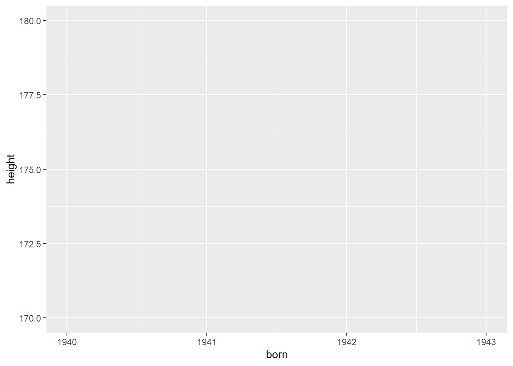

```r
ggplot(data = beatles, mapping = aes(x = born, y = height))
```

ここに点のレイヤーを `geom_point` 関数で追加する．

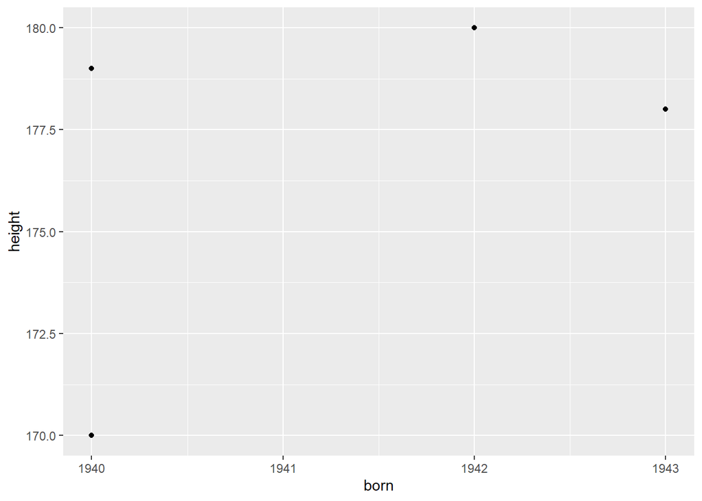

```r
ggplot(data = beatles, mapping = aes(x = born, y = height)) +
  geom_point()
```

下のようにコーディングしてもよい．

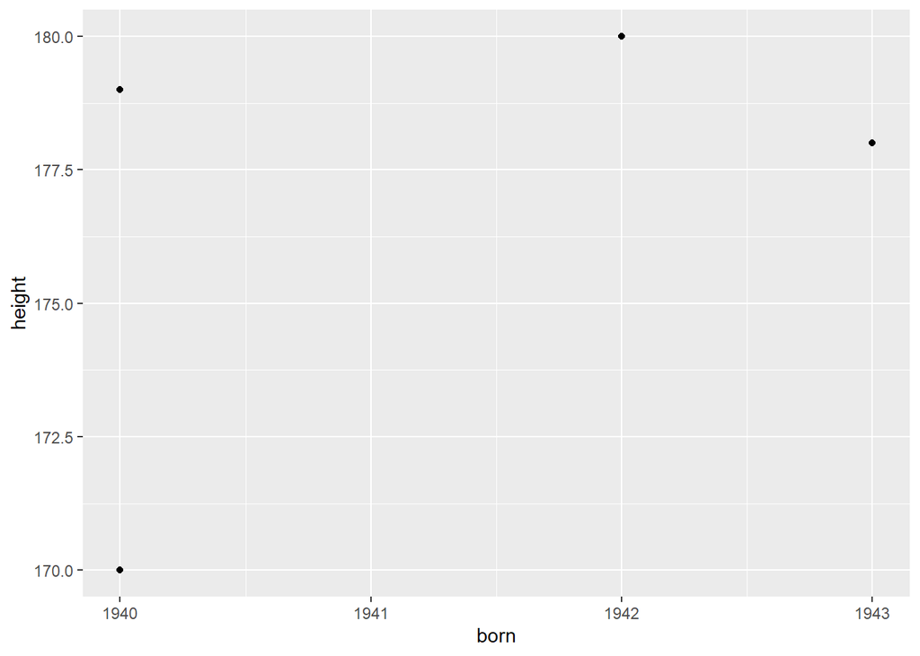

```r
ggplot() +
  geom_point(data = beatles, mapping = aes(x = born, y = height))
```

軸のラベルを変更する．

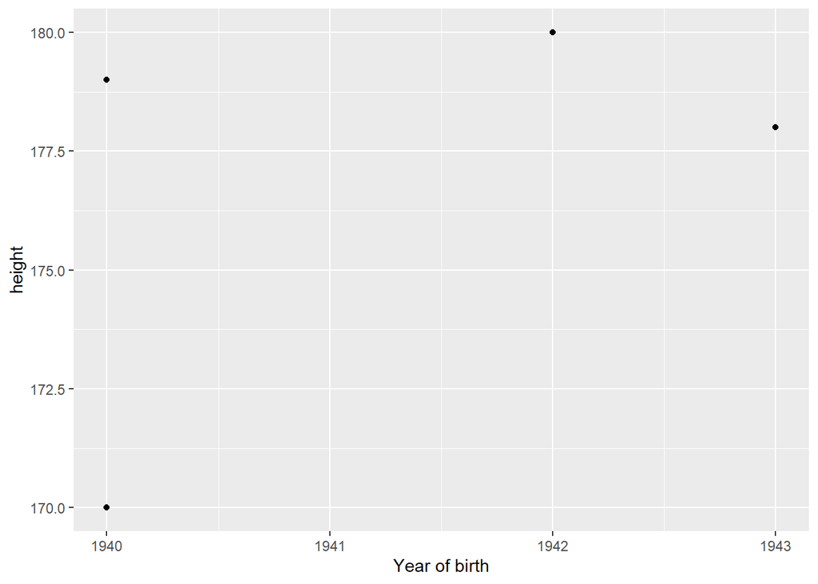

```r
ggplot(data = beatles, mapping = aes(x = born, y = height)) +
  geom_point() +
  xlab("Year of birth")
```

キャンバスのテーマを変える．

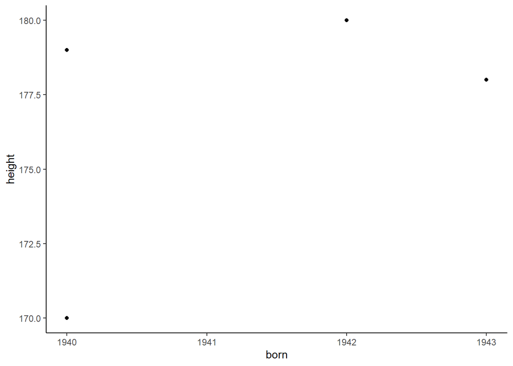

```r
ggplot(data = beatles, mapping = aes(x = born, y = height)) +
  geom_point() +
  theme_classic()
```

# 3 Example of `swiss` data

Learn the basic usage of the tidyverse using the `swiss` data built-in to R.

Rにビルトインされているswissデータを用いて，tidyverseの基本的な使い方を確認します．

You can find the other built-in datasets using `data()`.

他にビルトインされているデータセットは `data()` で確認できます．

For ease of understanding, we cut out only the first six rows (provinces) and the first four columns (variables) of the `swiss` dataset and define it as a new dataset named `swiss2`.

理解しやすいように，swissデータセットの最初の6行（provinces）と最初の4列（variables）だけを切り出して，「swiss2」という名前の新しいデータセットとして定義します．

```r
swiss2 <- swiss[1:6, 1:4]  # Extract a portion of `swiss` dataset
swiss2
```

```
##              Fertility Agriculture Examination Education
## Courtelary        80.2        17.0          15        12
## Delemont          83.1        45.1           6         9
## Franches-Mnt      92.5        39.7           5         5
## Moutier           85.8        36.5          12         7
## Neuveville        76.9        43.5          17        15
## Porrentruy        76.1        35.3           9         7
```

## 3.1 `filter`, `select`, `mutate`, `rename`, and `summarise`

```r
swiss2 %>% filter(Fertility > 80)  # Keep only provinces with a "Fertility" greater than 80
```

```
##              Fertility Agriculture Examination Education
## Courtelary        80.2        17.0          15        12
## Delemont          83.1        45.1           6         9
## Franches-Mnt      92.5        39.7           5         5
## Moutier           85.8        36.5          12         7
```

```r
filter(swiss2, Fertility > 80)  # same as above
```

```
##              Fertility Agriculture Examination Education
## Courtelary        80.2        17.0          15        12
## Delemont          83.1        45.1           6         9
## Franches-Mnt      92.5        39.7           5         5
## Moutier           85.8        36.5          12         7
```

```r
swiss2 %>% filter(Fertility > 80, Examination > 10)  # multiple conditions
```

```
##            Fertility Agriculture Examination Education
## Courtelary      80.2        17.0          15        12
## Moutier         85.8        36.5          12         7
```

```r
swiss2 %>% select(Fertility, Examination)  # select specified variables
```

```
##              Fertility Examination
## Courtelary        80.2          15
## Delemont          83.1           6
## Franches-Mnt      92.5           5
## Moutier           85.8          12
## Neuveville        76.9          17
## Porrentruy        76.1           9
```

```r
swiss2 %>% mutate(Exam_Edu = (Examination + Education)/2)  # creates new variable as the mean
```

```
##              Fertility Agriculture Examination Education Exam_Edu
## Courtelary        80.2        17.0          15        12     13.5
## Delemont          83.1        45.1           6         9      7.5
## Franches-Mnt      92.5        39.7           5         5      5.0
## Moutier           85.8        36.5          12         7      9.5
## Neuveville        76.9        43.5          17        15     16.0
## Porrentruy        76.1        35.3           9         7      8.0
```

```r
swiss2 %>% rename(Exam = Examination)  # new name is `Exam`, old name is `Examination`
```

```
##              Fertility Agriculture Exam Education
## Courtelary        80.2        17.0   15        12
## Delemont          83.1        45.1    6         9
## Franches-Mnt      92.5        39.7    5         5
## Moutier           85.8        36.5   12         7
## Neuveville        76.9        43.5   17        15
## Porrentruy        76.1        35.3    9         7
```

```r
swiss2 %>% summarise(mean_fert = mean(Fertility), sd_fert = sd(Fertility),
                     median_fert = median(Fertility), mean_educ = mean(Education))
```

```
##   mean_fert  sd_fert median_fert mean_educ
## 1  82.43333 6.145459       81.65  9.166667
```

`summarise` を使わないで計算する場合は以下のようになる．

```r
mean(swiss2$Fertility); sd(swiss2$Fertility); median(swiss2$Fertility); mean(swiss2$Education)
```

```
## [1] 82.43333
```

```
## [1] 6.145459
```

```
## [1] 81.65
```

```
## [1] 9.166667
```

## 3.2 `group_by` and `summarise`

We can also compare states with high fertility rates with provinces with low fertility rates. To do so, add a variable called `high_fertility_province` that indicates whether the province has a high fertility rate or not, and use the `group_by` function with this variable.

出生率が高いか低いかでグループを分けて，そのグループごとに平均値や分散などを計算することもできます．その場合は出生率が高いかどうかを示す `high_fertility_province` という変数を作成し，それを `group_by` 関数に使用します．

```r
swiss2 %>%
  mutate(high_fertility_province = Fertility > mean(Fertility)) %>%
  group_by(high_fertility_province) %>%
  summarize(mean_fert = mean(Fertility), mean_exam = mean(Examination))
```

```
## # A tibble: 2 × 3
##   high_fertility_province mean_fert mean_exam
##   <lgl>                       <dbl>     <dbl>
## 1 FALSE                        77.7     13.7
## 2 TRUE                         87.1      7.67
```

先ほどと同様に `group_by` や `summarise` 関数を使わずに同じものを計算しようとすると以下のようになる． `group_by` 関数の便利さと可読性がおわかりいただけるだろう．

```r
mean(swiss2$Fertility[swiss2$Fertility > mean(swiss2$Fertility)])
```

```
## [1] 87.13333
```

```r
mean(swiss2$Fertility[swiss2$Fertility <= mean(swiss2$Fertility)])
```

```
## [1] 77.73333
```

```r
mean(swiss2$Examination[swiss2$Fertility > mean(swiss2$Fertility)])
```

```
## [1] 7.666667
```

```r
mean(swiss2$Examination[swiss2$Fertility <= mean(swiss2$Fertility)])
```

```
## [1] 13.66667
```

If the dataset organized as described above is to be used for future analysis, the original dataset may be overwritten or a new dataset may be created (create a new object called `swiss2_new`).

Overwriting the original dataset (`swiss2`) will cause the original dataset to disappear from R, so I recommend assigning it to a new object (`swiss2_new`).

上記の操作を行ったデータセットを今後の分析に使用する場合，元のデータセットを上書きしてもよいですし，新しいデータセットを作成してもよいですが，上書きすると元のデータはR上から消えますので注意してください．

```r
swiss2_new <- swiss2 %>% filter(Fertility > 90)  # create new
swiss2 <- swiss2 %>% filter(Fertility > 90)  # overwrite
```

## 3.3 `left_join`

Two datasets can be merged using the `left_join` function. For example, the dataset swiss2_pop contains two variables: province name and population.

2つのデータセットがある場合，`left_join` 関数を使って統合することができます．たとえば，swiss2_pop というデータセットには州の名前と人口の2つの変数があるとしましょう．

```r
swiss2 <- swiss[1:6, 1:4]
swiss2b <- swiss2 %>% mutate(prov = rownames(swiss2))  # add province names as a column "prov"
swiss2b
```

```
##              Fertility Agriculture Examination Education         prov
## Courtelary        80.2        17.0          15        12   Courtelary
## Delemont          83.1        45.1           6         9     Delemont
## Franches-Mnt      92.5        39.7           5         5 Franches-Mnt
## Moutier           85.8        36.5          12         7      Moutier
## Neuveville        76.9        43.5          17        15   Neuveville
## Porrentruy        76.1        35.3           9         7   Porrentruy
```

```r
swiss2_pop <- data.frame(prov = c("Courtelary", "Delemont", "Franches-Mnt",
                                  "Moutier", "Neuveville", "Porrentruy"),
                         pop = c(100, 200, 300, 400, 500, 600))
swiss2_pop
```

```
##           prov pop
## 1   Courtelary 100
## 2     Delemont 200
## 3 Franches-Mnt 300
## 4      Moutier 400
## 5   Neuveville 500
## 6   Porrentruy 600
```

```r
swiss2b %>% left_join(swiss2_pop, by = "prov")
```

```
##   Fertility Agriculture Examination Education         prov pop
## 1      80.2        17.0          15        12   Courtelary 100
## 2      83.1        45.1           6         9     Delemont 200
## 3      92.5        39.7           5         5 Franches-Mnt 300
## 4      85.8        36.5          12         7      Moutier 400
## 5      76.9        43.5          17        15   Neuveville 500
## 6      76.1        35.3           9         7   Porrentruy 600
```

In the above example, the state order in the dataset named `swiss2b` and the state order in the dataset named `swiss2_pop` are the same, but they can be merged even if they are different. It is also possible to merge even if there is not all the data in `swiss2_pop`.

上記の例では，`swiss2b` というデータセットの州の並びと `swiss2_pop` というデータセットの州の並びが同じでしたが，異なっている場合でもマージ可能です．また，`swiss2_pop` にすべての州のデータがなかったとしてもマージ可能です．

```r
swiss2_pop <- data.frame(prov = c("Porrentruy", "Courtelary", "Delemont",
                                  "Franches-Mnt", "Neuveville"),
                         pop = c(600, 100, 200, 300, 500))
swiss2_pop
```

```
##           prov pop
## 1   Porrentruy 600
## 2   Courtelary 100
## 3     Delemont 200
## 4 Franches-Mnt 300
## 5   Neuveville 500
```

```r
swiss2b %>% left_join(swiss2_pop, by = "prov")
```

```
##   Fertility Agriculture Examination Education         prov pop
## 1      80.2        17.0          15        12   Courtelary 100
## 2      83.1        45.1           6         9     Delemont 200
## 3      92.5        39.7           5         5 Franches-Mnt 300
## 4      85.8        36.5          12         7      Moutier  NA
## 5      76.9        43.5          17        15   Neuveville 500
## 6      76.1        35.3           9         7   Porrentruy 600
```

## 3.4 Scatter plot using `ggplot2`

ビートルズのデータと同様に散布図を描いてみる．

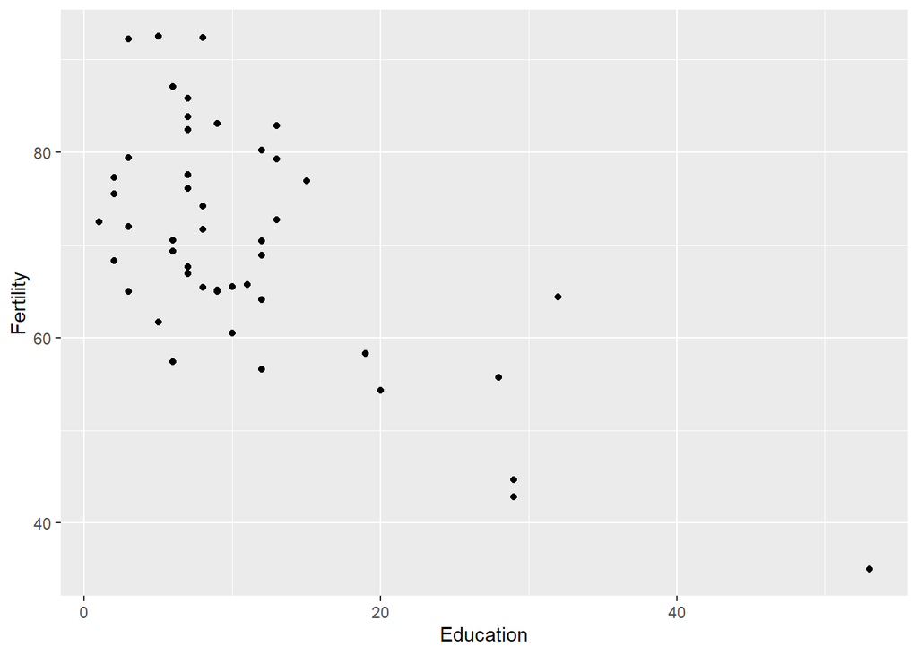

```r
ggplot(data = swiss, mapping = aes(x = Education, y = Fertility)) +
  geom_point()
```

マーカーの色をカトリック教徒の割合（%）で指定するには `aes` で指定する．

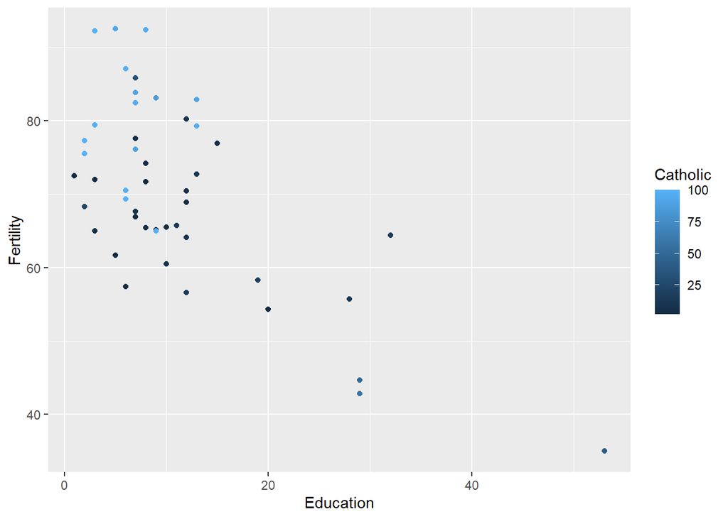

```r
ggplot(data = swiss, mapping = aes(x = Education, y = Fertility, color = Catholic)) +
  geom_point()
```

`swiss` データを加工して描画に使用する場合は下のようにコーディングしてもよい． このとき，`ggplot` 関数の一つ目の引数 `data` として `ggplot` 関数の直前のデータが指定される．

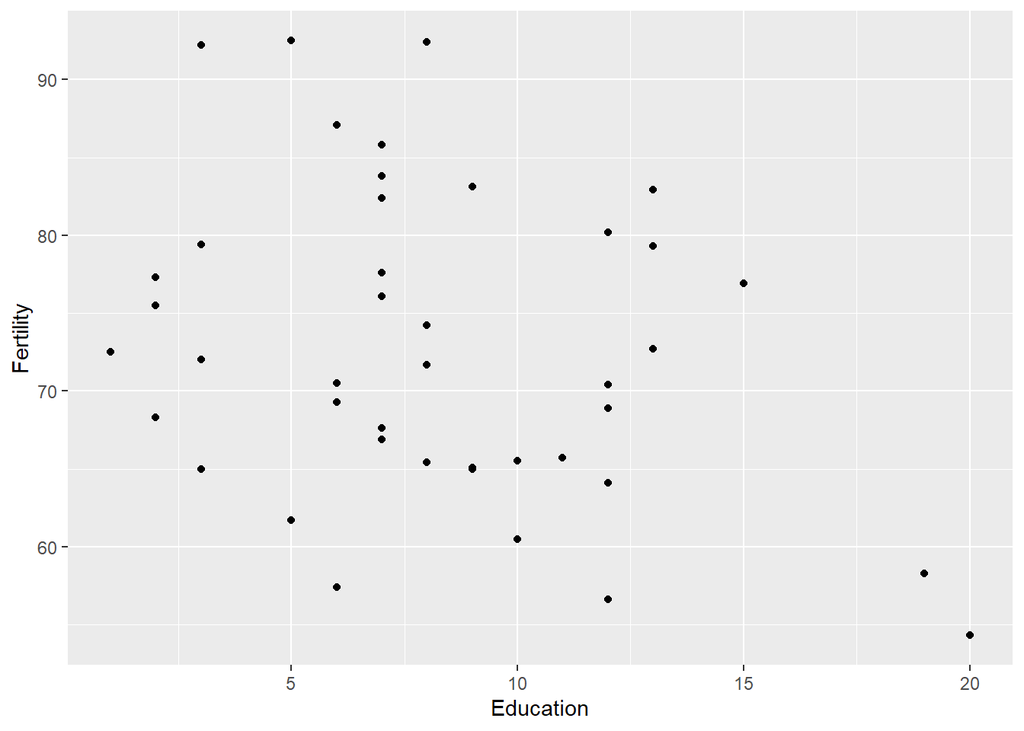

```r
swiss %>%
  filter(Education <= 20) %>%
  ggplot(mapping = aes(x = Education, y = Fertility)) +
  geom_point()
```

データポイントにフィットする曲線のレイヤーを追加する．

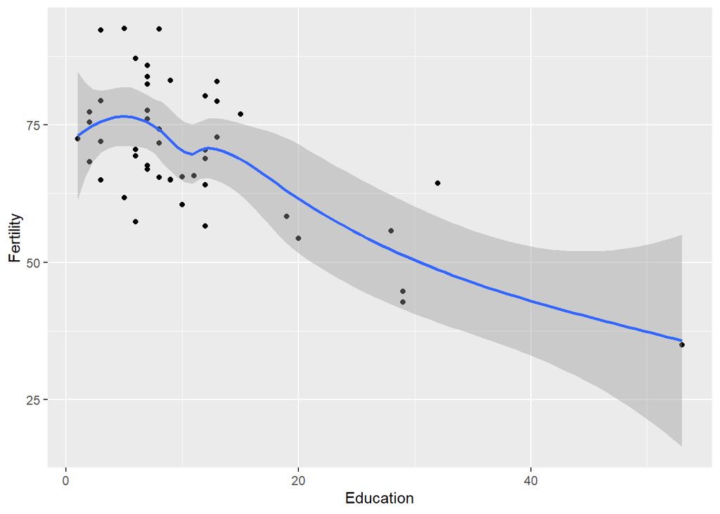

```r
ggplot(data = swiss, mapping = aes(x = Education, y = Fertility)) +
  geom_point() +
  geom_smooth()
```

# 4 Example of Titanic data

```r
titanic <- read.csv("https://raw.githubusercontent.com/kurodaecon/bs/main/data/titanic3_csv.csv")
```

## 4.1 `filter`

```r
titanic %>% filter(age > 75)
```

```
##   pclass survived    sex age sibsp parch  fare embarked
## 1      1        1   male  80     0     0 30.00        S
## 2      1        1 female  76     1     0 78.85        S
```

## 4.2 `group_by` and `summarise`

性別ごとの生存率．

```r
titanic %>%
  group_by(sex) %>%
  summarize(survival_rate = mean(survived),
            sample_size = n())
```

```
## # A tibble: 2 × 3
##   sex    survival_rate sample_size
##   <chr>          <dbl>       <int>
## 1 female         0.727         466
## 2 male           0.191         843
```

性別と客室等級ごとの生存率．

```r
titanic %>%
  group_by(sex, pclass) %>%
  summarize(survival_rate = mean(survived),
            sample_size = n())
```

```
## # A tibble: 6 × 4
## # Groups:   sex [2]
##   sex    pclass survival_rate sample_size
##   <chr>   <int>         <dbl>       <int>
## 1 female      1         0.965         144
## 2 female      2         0.887         106
## 3 female      3         0.491         216
## 4 male        1         0.341         179
## 5 male        2         0.146         171
## 6 male        3         0.152         493
```

性別と年齢層ごとの生存率．

```r
titanic %>%
  mutate(age_group = cut(age, breaks = c(0, 20, 60, 100), right = FALSE)) %>%
  group_by(sex, age_group) %>%
  summarize(survival_rate = mean(survived),
            sample_size = n())
```

```
## # A tibble: 8 × 4
## # Groups:   sex [2]
##   sex    age_group survival_rate sample_size
##   <chr>  <fct>             <dbl>       <int>
## 1 female [0,20)            0.699         103
## 2 female [20,60)           0.770         274
## 3 female [60,100)          0.818          11
## 4 female <NA>              0.603          78
## 5 male   [0,20)            0.279         122
## 6 male   [20,60)           0.193         507
## 7 male   [60,100)          0.103          29
## 8 male   <NA>              0.141         185
```

性別と客室等級と年齢層ごとの生存率．

```r
titanic %>%
  mutate(age_group = cut(age, breaks = c(0, 20, 60, 100), right = FALSE)) %>%
  group_by(sex, pclass, age_group) %>%
  summarize(survival_rate = mean(survived),
            sample_size = n())
```

```
## # A tibble: 24 × 5
## # Groups:   sex, pclass [6]
##    sex    pclass age_group survival_rate sample_size
##    <chr>   <int> <fct>             <dbl>       <int>
##  1 female      1 [0,20)            0.938          16
##  2 female      1 [20,60)           0.972         108
##  3 female      1 [60,100)          0.889           9
##  4 female      1 <NA>              1              11
##  5 female      2 [0,20)            0.958          24
##  6 female      2 [20,60)           0.885          78
##  7 female      2 [60,100)          0               1
##  8 female      2 <NA>              0.667           3
##  9 female      3 [0,20)            0.540          63
## 10 female      3 [20,60)           0.420          88
## # … with 14 more rows
```

カテゴリー数が多いためにすべて表示されていない． 以下のように表示数を調整できる．

```r
titanic %>%
  mutate(age_group = cut(age, breaks = c(0, 20, 60, 100), right = FALSE)) %>%
  group_by(sex, pclass, age_group) %>%
  summarize(survival_rate = mean(survived),
            sample_size = n()) %>%
  print(n = 30)
```

```
## # A tibble: 24 × 5
## # Groups:   sex, pclass [6]
##    sex    pclass age_group survival_rate sample_size
##    <chr>   <int> <fct>             <dbl>       <int>
##  1 female      1 [0,20)           0.938           16
##  2 female      1 [20,60)          0.972          108
##  3 female      1 [60,100)         0.889            9
##  4 female      1 <NA>             1               11
##  5 female      2 [0,20)           0.958           24
##  6 female      2 [20,60)          0.885           78
##  7 female      2 [60,100)         0                1
##  8 female      2 <NA>             0.667            3
##  9 female      3 [0,20)           0.540           63
## 10 female      3 [20,60)          0.420           88
## 11 female      3 [60,100)         1                1
## 12 female      3 <NA>             0.531           64
## 13 male        1 [0,20)           0.6             10
## 14 male        1 [20,60)          0.363          124
## 15 male        1 [60,100)         0.118           17
## 16 male        1 <NA>             0.286           28
## 17 male        2 [0,20)           0.444           27
## 18 male        2 [20,60)          0.0806         124
## 19 male        2 [60,100)         0.143            7
## 20 male        2 <NA>             0.154           13
## 21 male        3 [0,20)           0.188           85
## 22 male        3 [20,60)          0.166          259
## 23 male        3 [60,100)         0                5
## 24 male        3 <NA>             0.111          144
```

年齢の平均を計算しようとすると `NA` が返ってくる．

```r
titanic %>%
  summarise(age_mean = mean(age))
```

```
##   age_mean
## 1       NA
```

これは年齢変数 `age` に `NA` が含まれるため． `na.rm = TRUE` 引数を追加する．

```r
titanic %>%
  summarise(age_mean = mean(age, na.rm = TRUE))
```

```
##   age_mean
## 1 29.88114
```

## 4.3 Histogram using `ggplot2`

年齢．

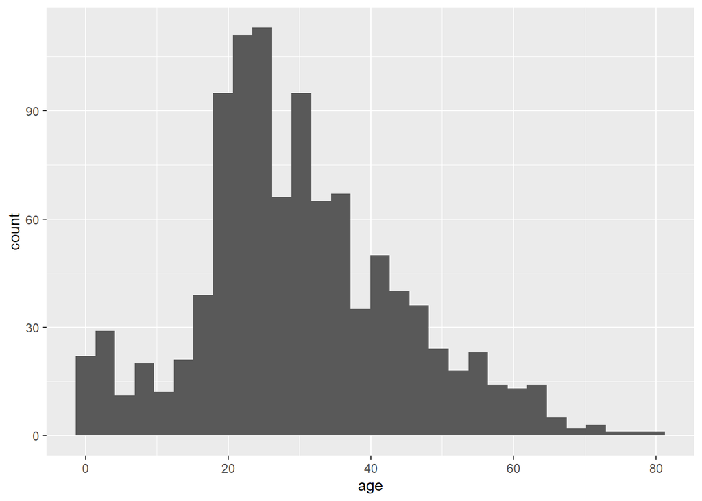

```r
ggplot(data = titanic, mapping = aes(x = age)) +
  geom_histogram()
```

性別ごとに分ける．

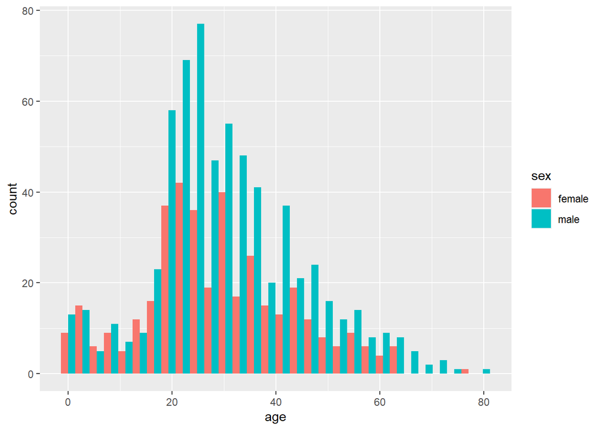

```r
ggplot(data = titanic, mapping = aes(x = age, fill = sex)) +
  geom_histogram(position = "dodge")
```

## 4.4 Bar plot using `ggplot2`

出港地ごとの人数．

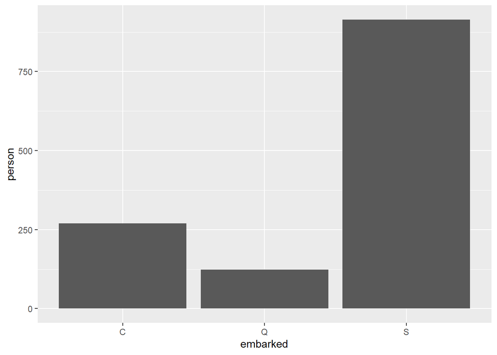

```r
titanic %>%
  filter(embarked != "") %>%
  group_by(embarked) %>%
  summarise(person = n()) %>%
  ggplot(mapping = aes(x = embarked, y = person)) +
  geom_bar(stat = "identity")
```

性別ごとに分ける． ついでにX軸のラベルも修正しておく．

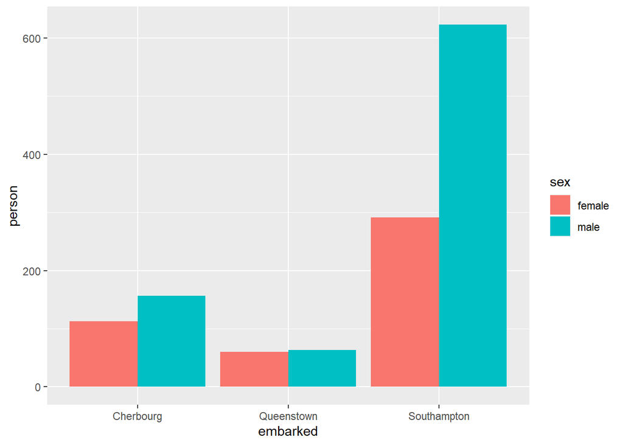

```r
titanic %>%
  filter(embarked != "") %>%
  group_by(embarked, sex) %>%
  summarise(person = n()) %>%
  ggplot(mapping = aes(x = embarked, y = person, fill = sex)) +
  geom_bar(stat = "identity", position = "dodge") +
  scale_x_discrete(labels = c("Cherbourg", "Queenstown", "Southampton"))
```

## 4.5 Pie chart using `ggplot2`

出港地ごとの人数．

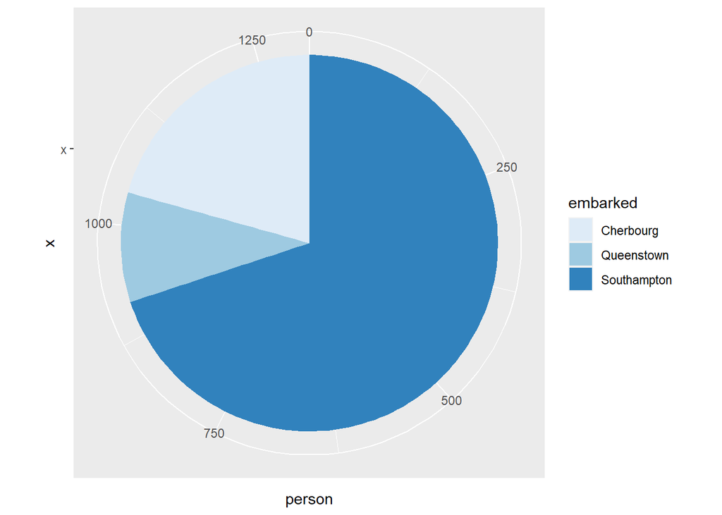

```r
titanic %>%
  filter(embarked != "") %>%
  group_by(embarked) %>%
  summarise(person = n()) %>%
  ggplot(mapping = aes(x = "x", y = person, fill = embarked)) +
  geom_bar(stat = "identity", position = "stack") +
  coord_polar(theta = "y") +
  scale_fill_brewer(labels = c("Cherbourg", "Queenstown", "Southampton"))
```

## 4.6 Boxplot using `ggplot2`

年齢．

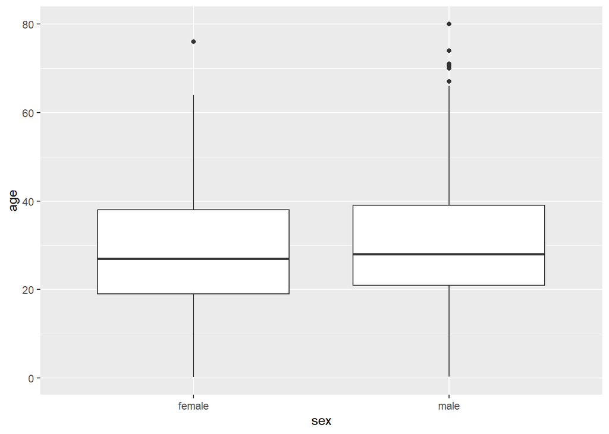

```r
ggplot(data = titanic, mapping = aes(x = sex, y = age)) +
  geom_boxplot()
```

客室等級ごとの年齢．

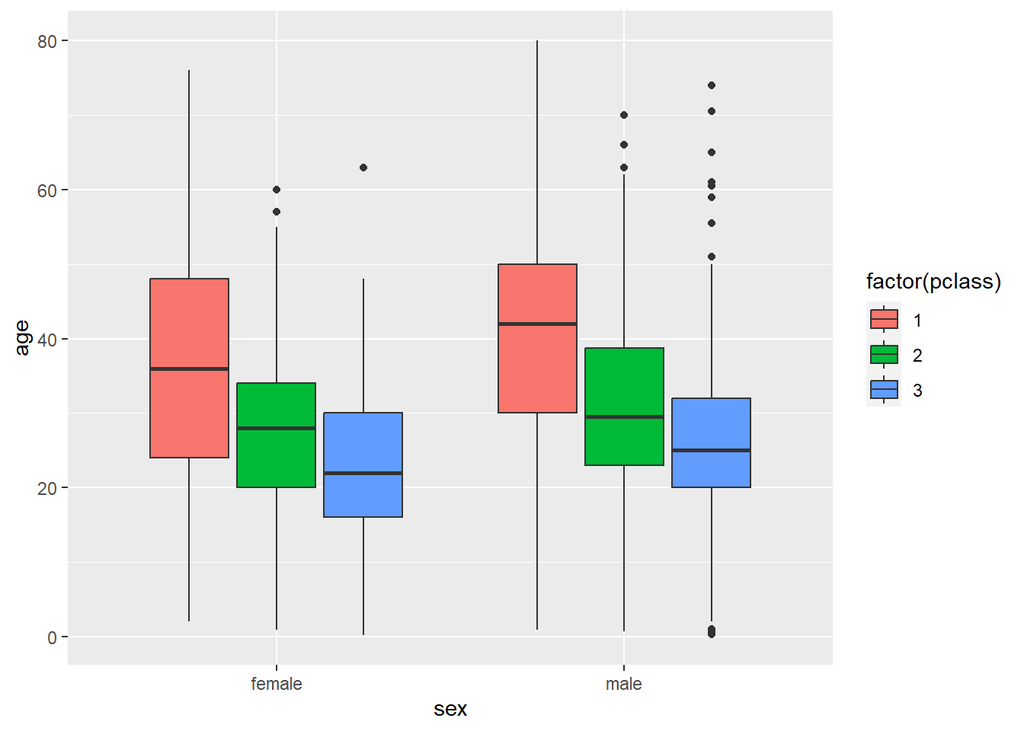

```r
ggplot(data = titanic, mapping = aes(x = sex, y = age, fill = factor(pclass))) +
  geom_boxplot()
```

データの分布が複雑な場合（多峰など），バイオリンプロットという選択肢がある．

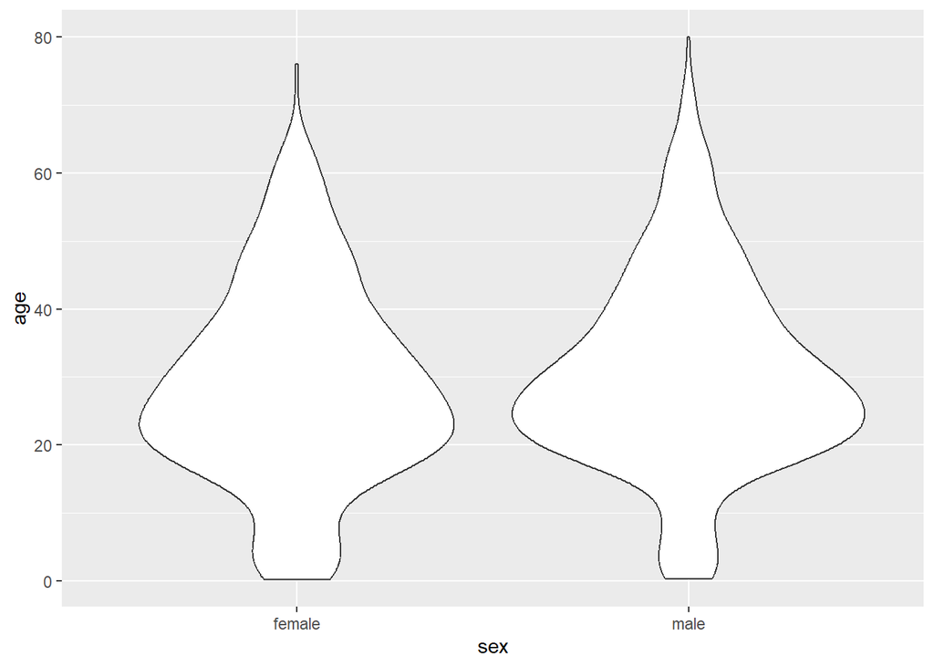

```r
ggplot(data = titanic, mapping = aes(x = sex, y = age)) +
  geom_violin()
```

## 4.7 Scatter plot using `ggplot2`

ビートルズやSwissデータと同様に散布図を描き，スムージング曲線を追加する．

点同士が重なってしまうため `geom_jitter` 関数でY軸方向にばらつかせて描画．

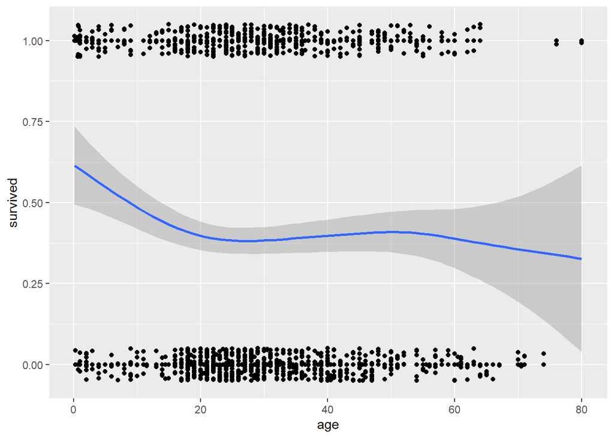

```r
ggplot(data = titanic, mapping = aes(x = age, y = survived)) +
  geom_point() +
  geom_jitter(height = .05, width = 0) +
  geom_smooth()
```

あるいはBinned plotを作成してもよいだろう．

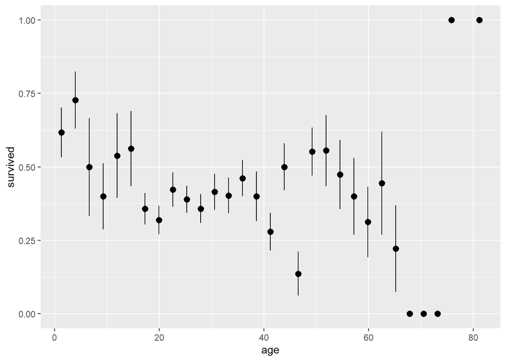

```r
ggplot(data = titanic, mapping = aes(x = age, y = survived)) +
  stat_summary_bin()
```

性別による死亡率の違いを示す．

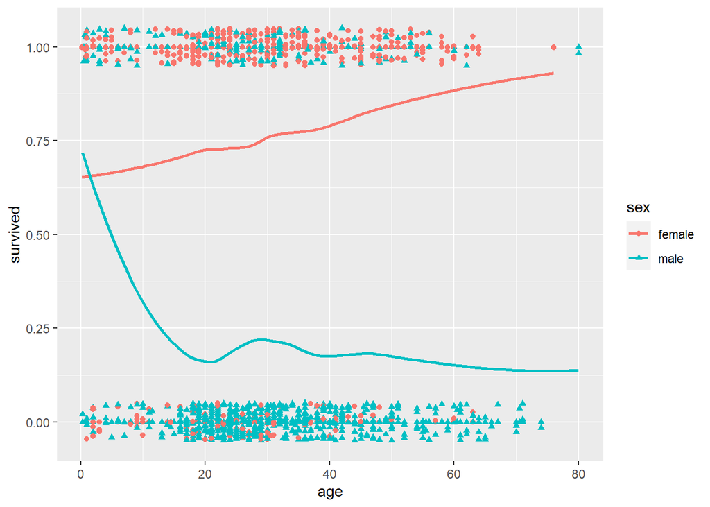

```r
ggplot(data = titanic, mapping = aes(x = age, y = survived, color = sex, shape = sex)) +
  geom_point() +
  geom_jitter(height = .05, width = 0) +
  geom_smooth(aes(color = sex), se = FALSE)
```

客室等級による死亡率の違いを示す．

注：`pclass` は連続変数なので，`factor` 関数で因子型の変数に変換して使う．

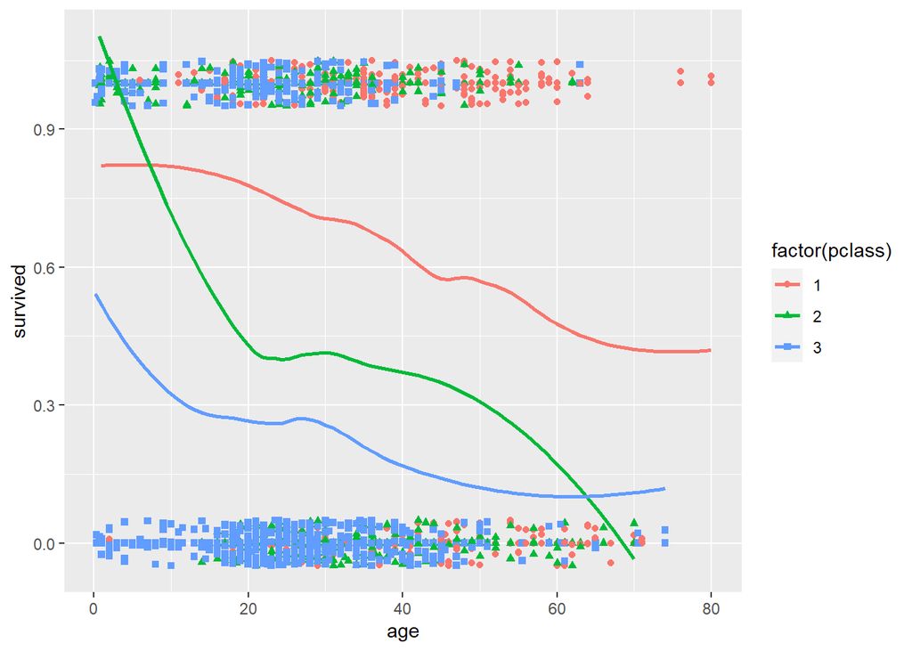

```r
ggplot(data = titanic, mapping = aes(x = age, y = survived, color = factor(pclass), shape = factor(pclass))) +
  geom_point() +
  geom_jitter(height = .05, width = 0) +
  geom_smooth(aes(color = factor(pclass)), se = FALSE)
```

性別ごとに独立した散布図を作成してそれぞれのパネルを並べた図を作ることもできる．

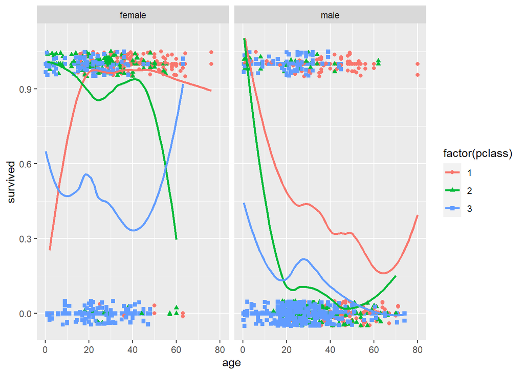

```r
ggplot(data = titanic, mapping = aes(x = age, y = survived, color = factor(pclass), shape = factor(pclass))) +
  geom_point() +
  geom_jitter(height = .05, width = 0) +
  geom_smooth(aes(color = factor(pclass)), se = FALSE) +
  facet_wrap(~ sex)
```

.